# Notebook 3

## Jupyter notebook 3 : facteurs individuels

### Dans ce notebook, on va étudier le possibe impact sur le taux de suicide de facteurs qui prennent en compte l'état des individus, plus que de la société elle même.

### Facteurs sélectionnés

```
- mortalité infantile
- chomage
- tabagisme
- alcoolisme
- consomation de drogues
```

On va chercher pour chaque facteur sa possible corélation avec le taux de suicide, pour à terme sélectionner les facteurs les plus représentatifs qu'on utilisera pour réaliser un modèle prédictif grace à sickyt learn.

Importation de la bibliothèque et des jeux de donné et des bibliotèques

```python
import pandas as pd

dfMort = pd.read_csv('./Data/mortalite_moins5.csv', sep=',')
dfChom = pd.read_csv('./Data/chomage.csv', sep=',')
dfSmoke = pd.read_csv('./Data/smoking_part.csv', sep=',')
dfDrug = pd.read_csv('./Data/drug.csv', sep=',')
dfAlc = pd.read_csv('./Data/alcohol.csv', sep=',')

dfAS = pd.read_csv('./Data/age-standardized.csv', sep=',')
```

On crée un tableau regroupant l'ensemble de ces paramètres

```python
dfMort = dfMort.drop('Country', axis = 1 )
df = dfChom.merge(dfMort, left_on = 'Country Code', right_on ='Country Code')
df = df.merge(dfSmoke, left_on = 'Country Code', right_on ='Code')
df = df.drop('Code', axis = 1)
df = df.merge(dfDrug, left_on = 'Country Code', right_on ='Code')
df = df.drop('Code', axis = 1)
df = df.merge(dfAlc, left_on = 'Country Code', right_on ='Code')
df = df.drop('Code', axis = 1)
df = df.merge(dfAS, left_on = 'Country', right_on ='Country')
df = df.drop(103, axis = 0)
df = df.drop(59, axis = 0)

for i in range (4,df.shape[1]) :
    pd.to_numeric(df.iloc[:,i])
```

```python
df = df.sort_index()
df.head(5)
```

|  | Country | Country Code | Unemployement (%) 2016 | Mortality under 5 for 1000 (2016) | Smoking (%) | Drug use disorders (%) | Alcohol (litres per capita) | Age standardized suicide rate |
| --- | --- | --- | --- | --- | --- | --- | --- | --- |
| 0 | Albania | ALB | 15.220000 | 9.3 | 28.7 | 0.515036 | 7.5 | 5.6 |
| 1 | Algeria | DZA | 10.202000 | 24.5 | 15.6 | 1.714025 | 0.9 | 3.3 |
| 2 | Argentina | ARG | 8.016000 | 10.9 | 21.8 | 0.999099 | 9.8 | 9.1 |
| 3 | Armenia | ARM | 17.617001 | 13.7 | 24.1 | 0.499895 | 5.5 | 5.7 |
| 4 | Australia | AUS | 5.711000 | 3.8 | 14.7 | 2.237198 | 10.6 | 11.7 |

## Etude des facteurs

Maintenant, on réalise des courbes pour chercher d'éventuelles corrélations.

A chaque graphique, on affiche le taux de suicide en fonction du facteur pris en compte

## Mortalité infantile

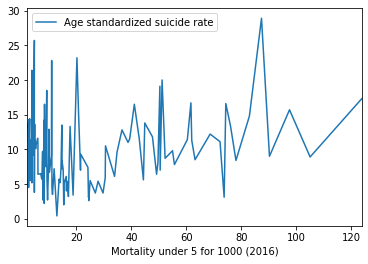

```python
df = df.sort_values( by = 'Mortality under 5 for 1000 (2016)')
df.plot(x = 'Mortality under 5 for 1000 (2016)', y = 'Age standardized suicide rate');
```

Répartition en fréquence :

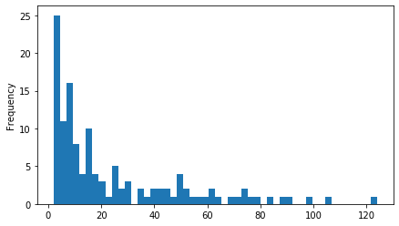

```python
df.iloc[:,3].plot.hist( figsize=(7,4), bins = 50);
```

On observe que la majorité des pays possèdent une faible mortalité infantile. Cependant pour d'autres, la mortalité est dispropostionnée par rapport à la médiane, une échelle logarithmique est plus appropriée pour afficher les données.

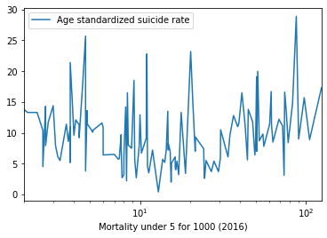

```python
df.plot(x = 'Mortality under 5 for 1000 (2016)', y = 'Age standardized suicide rate', logx = True);
```

### Conclusion :

Pour le taux de mortalité infantile, on a une répartition inégales entre les pays. Beaucoup de pays ont un taux de mortalité faible (<10), tandis que les les autres pays voient leur taux augmenter de façon exponentielle. On observe difficilement un lien jusqu'à un taux de 20, mais au delà une tendance montante se dessine

On peut donc supposer une corélation entre en la mortalité infantile et le taux de suicide

## Taux de chomage

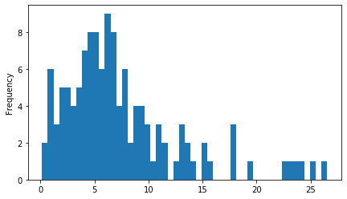

```python
df.iloc[:,2].plot.hist( figsize=(7,4), bins = 50);
```

De même que précédemment, une échelle logarithmique est plus approrié en raison de la répartition des données

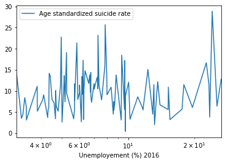

```python
df = df.sort_values( by = 'Unemployement (%) 2016')
# On affiche pas les pays au taux de chomage inférieur à 3 (correspond à des pays en dévelopement à la population majoritairement rurale et vivrière)
df[(df['Unemployement (%) 2016'] >= 3)].plot(x = 'Unemployement (%) 2016', y = 'Age standardized suicide rate', logx = True );
```

Echelle non logaritmique

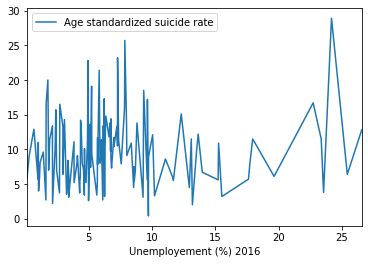

```python
df.plot(x = 'Unemployement (%) 2016', y = 'Age standardized suicide rate');
```

## Conclusion :

Pour le taux de chomage, on observe aucune tendance. On pourrait extrapoler sur les valeurs extrèmes (taux de chomage supérieur à 10) en disant qu'une montée du taux de suicide est observable pour un très fort taux de chomage. Cependant le nombre de données sur cette plage est trop faible pour pouvoir affirmer quoi que ce soit.

## Tabagisme

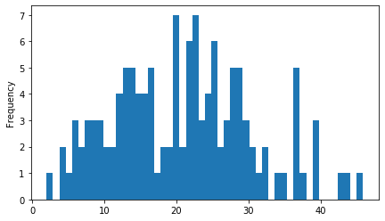

```python
df.iloc[:,4].plot.hist( figsize=(7,4), bins = 50);
```

On obtient une répartition gaussienne, une échelle normale est donc adaptée

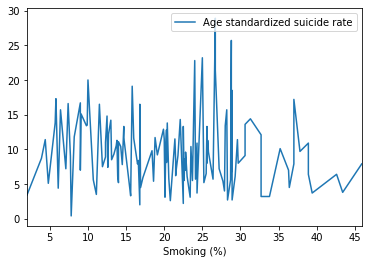

```python
df = df.sort_values( by = 'Smoking (%)')
df.plot(x = 'Smoking (%)', y = 'Age standardized suicide rate');
```

## Conclusion

La courbe liant le taux de suicide et le tabagisme est relativement constante, on peut supposer qu'il n'y a pas de lien entre les deux.

## Consomation de drogues

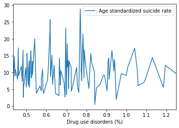

```python
df = df.sort_values( by = 'Drug use disorders (%)')
# on n'affiche pas les valeurs extrèmes pour avoir une meilleur visibilité.
df[df['Drug use disorders (%)'] < 1.25].plot(x = 'Drug use disorders (%)', y = 'Age standardized suicide rate');
```

## Conclusion

Rien non plus

## Alcoolisme

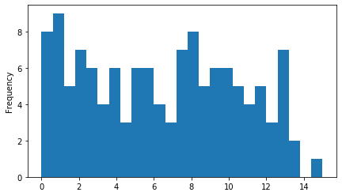

```python
df.iloc[:,6].plot.hist( figsize=(7,4), bins = 25);
```

répartition homogène

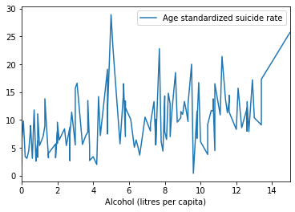

```python
df = df.sort_values( by = 'Alcohol (litres per capita)')
df.plot(x = 'Alcohol (litres per capita)', y = 'Age standardized suicide rate',);
```

## Conclusion :

# Modèle Prédictif

Maintenant, on va créer un modèle prédictif à partir des critères précédents

```python
import numpy as np
import statistics as st
from sklearn.preprocessing import Normalizer
from sklearn.model_selection import train_test_split
from sklearn import linear_model



from sklearn import tree
from sklearn import linear_model

#modele = linear_model.LinearRegression()
modele = tree.DecisionTreeRegressor()
#modele = linear_model.Lasso(alpha=0.1)

a = np.zeros((1000,5))

#X = df.iloc[0:,[4, 6]]
X = df.iloc[0:,2:7]
y = df.iloc[0:,7]

for i in range(0,1000) :

    X_train, X_test, y_train, y_test = train_test_split(X, y, test_size=0.3)

    transformer = Normalizer().fit(X_train)  # fit does nothing.
    transformer
    Normalizer()
    transformer.transform(X_train)

    transformer = Normalizer().fit(X_test)  # fit does nothing.
    transformer
    Normalizer()
    transformer.transform(X_test)


    modele = modele.fit(X_train,y_train)

    for j in range(0,5) :

        a[i][j] = modele.feature_importances_[j]

poid = [0,0,0,0,0]

for i in range(0,5) :
    for j in range(0,1000) :
        poid[i] = poid[i] + (moy[j][i])
    poid[i] = poid[i] / 1000
poid
```

[output not shown]

```python
import numpy as np
import statistics as st
from sklearn.preprocessing import Normalizer
from sklearn.model_selection import train_test_split
from sklearn import linear_model



from sklearn import tree
from sklearn import linear_model

modele = linear_model.LinearRegression()
#modele = tree.DecisionTreeRegressor()
#modele = linear_model.Lasso(alpha=0.1)

moy = []

X = df.iloc[0:,[3,4, 6]]
#X = df.iloc[0:,2:7]
y = df.iloc[0:,7]

for i in range(0,1000) :

    X_train, X_test, y_train, y_test = train_test_split(X, y, test_size=0.3)

    transformer = Normalizer().fit(X_train)  # fit does nothing.
    transformer
    Normalizer()
    transformer.transform(X_train)

    transformer = Normalizer().fit(X_test)  # fit does nothing.
    transformer
    Normalizer()
    transformer.transform(X_test)


    modele = modele.fit(X_train,y_train)

    moy.append(modele.score(X_test,y_test))

st.mean(moy)
```

```
0.24686637750126825
```